# Analysis of natural disasters: effects on health and the economy

# Results

Finally we can join fatalities and injuries in one table:

```r
library(dplyr)
library(plyr)
# aggregate FATALITIES and INJURIES by type of EVTYPE
agg.fatalites.and.injuries <- ddply(storm, .(EVTYPE), summarize, Total = sum(FATALITIES + INJURIES,  na.rm = TRUE))
agg.fatalites.and.injuries$type <- "fatalities and injuries"

# aggregate FATALITIES by type of EVTYPE
agg.fatalities <- ddply(storm, .(EVTYPE), summarize, Total = sum(FATALITIES, na.rm = TRUE))
agg.fatalities$type <- "fatalities"

# aggregate INJURIES by type of EVTYPE
agg.injuries <- ddply(storm, .(EVTYPE), summarize, Total = sum(INJURIES, na.rm = TRUE))
agg.injuries$type <- "injuries"

# combine all
agg.health <- rbind(agg.fatalities, agg.injuries)
agg.health_top<-head(agg.health[order(agg.health$Total, decreasing = TRUE),],n =20L)

health.by.EVTYPE <- join (agg.fatalities, agg.injuries, by="EVTYPE", type="inner")
health_top<-head(health.by.EVTYPE[order(health.by.EVTYPE$Total, decreasing = TRUE),], n =20L)
health_top
```

```
##             EVTYPE Total       type Total     type
## 159       HEATWAVE  3138 fatalities  9154 injuries
## 432        TORNADO  2277 fatalities 38035 injuries
## 96           FLOOD  1551 fatalities  8682 injuries
## 229      LIGHTNING   817 fatalities  5231 injuries
## 428  THUNDER STORM   756 fatalities  9545 injuries
## 481           WIND   688 fatalities  1976 injuries
## 17        BLIZZARD   379 fatalities  2697 injuries
## 305    RIP CURRENT   368 fatalities   232 injuries
## 11       AVALANCHE   224 fatalities   170 injuries
## 306   RIP CURRENTS   204 fatalities   297 injuries
## 90    EXTREME COLD   160 fatalities   231 injuries
## 196      HURRICANE   135 fatalities  1331 injuries
## 171     HEAVY SNOW   127 fatalities  1021 injuries
## 274           RAIN   113 fatalities   301 injuries
## 202            ICE   107 fatalities  2195 injuries
## 189      HIGH SURF   101 fatalities   152 injuries
## 478       WILDFIRE    75 fatalities   911 injuries
## 316           SEAS    70 fatalities    35 injuries
## 99             FOG    62 fatalities   734 injuries
## 435 TROPICAL STORM    58 fatalities   340 injuries
```

And doing the same with the economic variables:

```r
# aggregate PropDamage and CropDamage by type of EVTYPE
agg.propdmg.and.cropdmg <- ddply(storm, .(EVTYPE), summarize, Total = sum(property.damage + crop.damage,  na.rm = TRUE))
agg.propdmg.and.cropdmg$type <- "property and crop damage"

# aggregate PropDamage by type of EVTYPE
agg.prop <- ddply(storm, .(EVTYPE), summarize, Total = sum(property.damage, na.rm = TRUE))
agg.prop$type <- "property"

# aggregate INJURIES by type of EVTYPE
agg.crop <- ddply(storm, .(EVTYPE), summarize, Total = sum(crop.damage, na.rm = TRUE))
agg.crop$type <- "crop"

# combine all
agg.economic <- rbind(agg.prop, agg.crop)
agg.economic_top<-head(agg.economic[order(agg.economic$Total, decreasing = TRUE),],n =20L)


economic.by.EVTYPE <- join (agg.prop, agg.crop, by="EVTYPE", type="inner")
economic_top<-head(economic.by.EVTYPE[order(economic.by.EVTYPE$Total, decreasing = TRUE),],n =20L)
economic_top
```

```
##               EVTYPE        Total     type       Total type
## 96             FLOOD 167437469632 property 12360577200 crop
## 196        HURRICANE  85356410010 property  5516117800 crop
## 432          TORNADO  43694708799 property   414961520 crop
## 357      STORM SURGE  43323536000 property        5000 crop
## 130             HAIL  15732267048 property  3025954473 crop
## 428    THUNDER STORM  12576227478 property  1274178988 crop
## 435   TROPICAL STORM   7703890550 property   678346000 crop
## 17          BLIZZARD   7441709201 property   159504000 crop
## 481             WIND   6196146123 property   775520550 crop
## 478         WILDFIRE   4765114000 property   295472800 crop
## 316             SEAS   4651148650 property    25902500 crop
## 202              ICE   3968635610 property  5022114300 crop
## 274             RAIN   3241216190 property   804662800 crop
## 476 WILD/FOREST FIRE   3001829500 property   106796830 crop
## 55           DROUGHT   1046106000 property 13972566000 crop
## 229        LIGHTNING    933699447 property    12092090 crop
## 171       HEAVY SNOW    932589142 property   134653100 crop
## 475       WILD FIRES    624100000 property           0 crop
## 212        LANDSLIDE    324596000 property    20017000 crop
## 153        HAILSTORM    241000000 property           0 crop
```

## Answering the questions

### Across the United States, which types of events (as indicated in the EVTYPE variable) are most harmful with respect to population health?

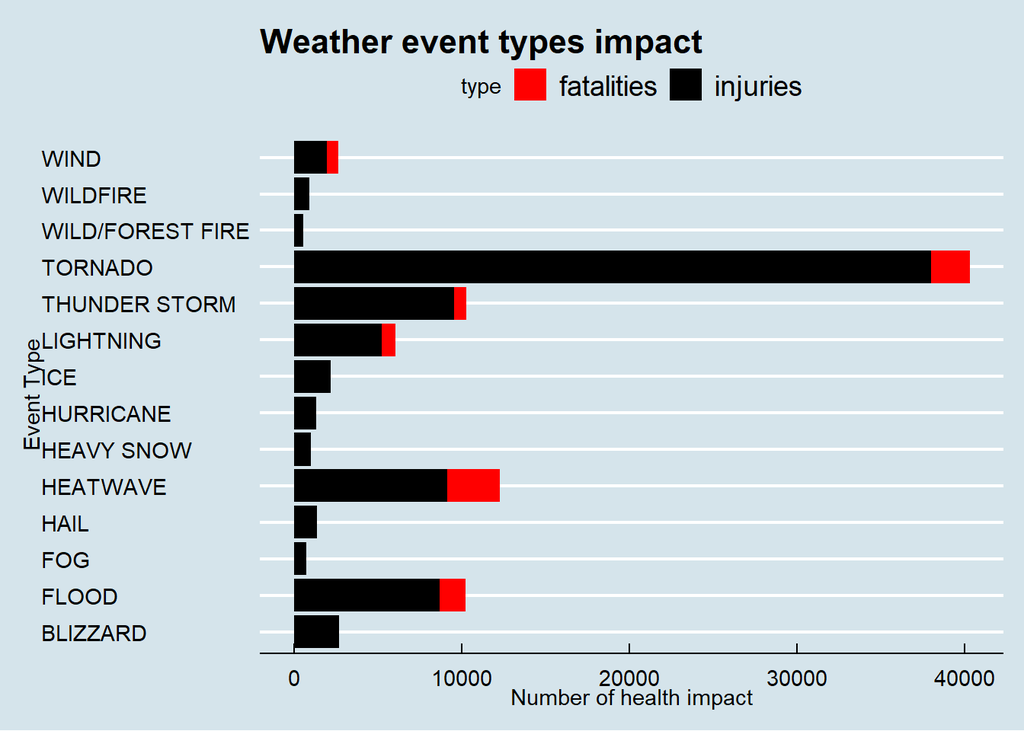

```r
library(ggplot2)
library(ggthemes)
health.plot <- ggplot(agg.health_top, aes(x = EVTYPE, y = Total, fill = type)) + geom_bar(stat = "identity") + coord_flip() + xlab("Event Type") + ylab("Number of health impact") +
  ggtitle("Weather event types impact") + scale_fill_manual(values=c("red","black")) + theme_economist()

print(health.plot)
```

*Tornadoes are the most damaging health events for our data set*

### Across the United States, which types of events have the greatest economic consequences?

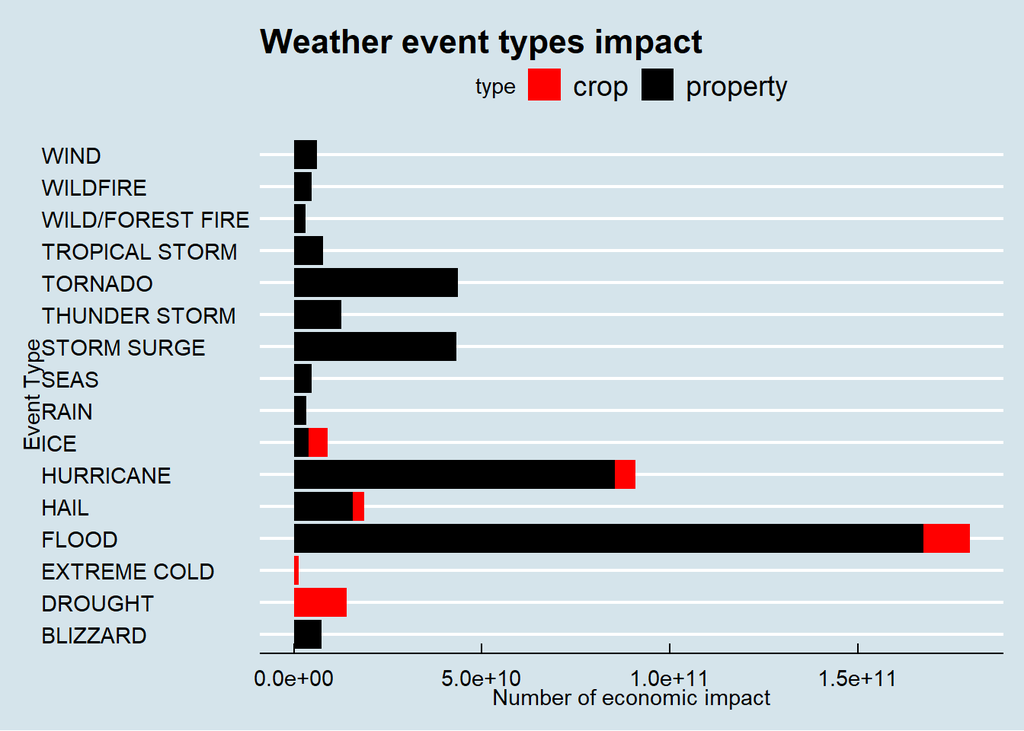

```r
economic.plot <- ggplot(agg.economic_top, aes(x = EVTYPE, y = Total, fill = type)) + geom_bar(stat = "identity") + coord_flip() + xlab("Event Type") + ylab("Number of economic impact") +
  ggtitle("Weather event types impact") + scale_fill_manual(values=c("red","black")) + theme_economist()

print(economic.plot)
```

*Francisco Javier Carela Ferrer*